# Customer Retention & Churn Analysis — UK Online Retail

Problem Based Learning - Business Intelligence Course

Jeronimo Ramos Ruiz

19 noviembre 2026

# Introduction

The dataset we will be working with comes from a UK-based non-store online retail company that specializes in unique all-occasion gifts. The company has been experiencing a significant drop in its customer retention rate. Many of its customers, especially wholesalers, have been discontinuing their business with the company. As a result, the company is facing challenges in maintaining its revenue and market share.

In this report we will analyze the transnational dataset, which contains all the transactions from 01/12/2010 to 09/12/2011, to build a predictive model for customer churn. The objective is to identify the factors that contribute to customer churn and develop a model that can predict which customers are most likely to discontinue their business with the company soon. This predictive model will enable the company to implement proactive retention strategies and improve its customer retention rate.

The analysis will consider various features such as transaction history, customer demographics, and purchasing behavior to develop an effective churn prediction model. Additionally, we will evaluate the model’s performance and provide actionable insights to the company’s management on how to reduce customer churn and enhance customer satisfaction.

# Objective

To build predictive models, such as regression and classification, to evaluate their performance using metrics and cross-validation, and support decision-making through data visualization and statistical analysis in R.

```r
source("config.R")
for (f in sort(list.files("R", pattern = "\\.R$", full.names = TRUE))) source(f)

require_packages(c("readxl", "readr", "lubridate", "tibble", "factoextra", "cluster",
                   "caret", "glmnet", "e1071", "kernlab"))
suppressPackageStartupMessages({
  library(dplyr); library(tidyr); library(ggplot2); library(knitr)
})
set.seed(CONFIG$seed)
```

# 1. Data import and cleaning

The dataset we will be working with comes from a UK-based non-store online retail company that specializes in unique all-occasion gifts. The company has been experiencing a significant drop in its customer retention rate. Many of its customers, especially wholesalers, have been discontinuing their business with the company. As a result, the company is facing challenges in maintaining its revenue and market share.

In this report we will analyze the transnational dataset, which contains all the transactions from 2010-12-01 08:26:00 to 2011-12-09 12:50:00, to build a predictive model for customer churn. To achieve this, we will use R as the primary analysis tool.

The dataset used contains information for each invoice, including the product code, its corresponding description, the quantity purchased, the unit price, and the date of purchase. Additionally, it includes two fields for the customer identifier and the country of origin.

In total, there are more than 500,000 records. However, before loading the data for analysis, a cleaning and preparation process was carried out. It involved removing product codes related to cancellations, discounts, taxes, bank commissions, or shipping costs. Additionally, invoice cancellations were removed, as well as missing values in the customer and invoice identifier columns and in the date field. Following this cleaning process, approximately 390,000 records remain (around 27.8% of data were dropped), corresponding to 4,334 unique customers.

```r
imp <- run_import_service(CONFIG$data_path)
kable(imp$quality_log, caption = "Data quality log")
```

Data quality log

| metric | value |
| --- | --- |
| Raw rows | 541909.0 |
| Clean transaction rows | 391150.0 |
| Unique customers | 4334.0 |
| Rows removed (%) | 27.8 |

# 2. Customer-level RFM and churn label

To identify the behavior of registered customers, the data were grouped by customer. For each customer, the following metrics were calculated: recency (the number of days since their last purchase), the total number of transactions, and a summary of their purchases—including the total value spent, as well as the minimum and average purchase amounts. Additionally, a binary variable was included to identify customers who have become inactive, based on the time elapsed since their last purchase: a value of 1 is assigned if the customer hasn’t made a purchase within the last 90 days, and 0 otherwise. As shown below:

```r
rfm_svc      <- run_rfm_service(imp$transactions)
rfm_raw      <- rfm_svc$rfm
rfm_features <- rfm_svc$rfm_features

kable(head(rfm_raw, 10), digits = 2, caption = "First customers (raw RFM values)")
```

First customers (raw RFM values)

| customer_id | recency | frequency | monetary_total | monetary_min | monetary_avg | churn | last_purchase |
| --- | --- | --- | --- | --- | --- | --- | --- |
| 12346 | 326.12 | 1 | 77183.60 | 77183.60 | 77183.60 | 1 | 2011-01-18 10:01:00 |
| 12347 | 2.87 | 7 | 4310.00 | 224.82 | 615.71 | 0 | 2011-12-07 15:52:00 |
| 12348 | 75.98 | 4 | 1437.24 | 187.44 | 359.31 | 0 | 2011-09-25 13:13:00 |
| 12349 | 19.12 | 1 | 1457.55 | 1457.55 | 1457.55 | 0 | 2011-11-21 09:51:00 |
| 12350 | 310.87 | 1 | 294.40 | 294.40 | 294.40 | 1 | 2011-02-02 16:01:00 |
| 12352 | 36.93 | 7 | 1385.74 | 104.35 | 197.96 | 0 | 2011-11-03 14:37:00 |
| 12353 | 204.79 | 1 | 89.00 | 89.00 | 89.00 | 1 | 2011-05-19 17:47:00 |
| 12354 | 232.99 | 1 | 1079.40 | 1079.40 | 1079.40 | 1 | 2011-04-21 13:11:00 |
| 12355 | 214.96 | 1 | 459.40 | 459.40 | 459.40 | 1 | 2011-05-09 13:49:00 |
| 12356 | 23.17 | 3 | 2487.43 | 58.35 | 829.14 | 0 | 2011-11-17 08:40:00 |

Thanks to the field created to identify customer churn, we can calculate a churn rate of **33.6%** (1458 of 4334 customers), which indicates that 3 out of every 10 customers have stopped purchasing products from the company.

# 3. Descriptive exploratory analysis

```r
eda <- run_eda_service(rfm_raw, rfm_features)

kable(eda$stats, digits = 2, caption = "Descriptive statistics (raw scale)")
```

Descriptive statistics (raw scale)

| variable | mean | median | sd | min | max |
| --- | --- | --- | --- | --- | --- |
| recency | 93.22 | 51.13 | 100.18 | 1.00 | 374.12 |
| frequency | 4.25 | 2.00 | 7.63 | 1.00 | 206.00 |
| monetary_total | 2015.97 | 662.57 | 8903.67 | 3.75 | 279138.02 |
| monetary_min | 264.11 | 168.11 | 1223.45 | 0.38 | 77183.60 |
| monetary_avg | 415.48 | 289.56 | 1800.90 | 3.75 | 84236.25 |

When attempting to represent the data in a histogram, it was observed that the data exhibit a positive skew, which makes it difficult to clearly distinguish the underlying patterns, as shown below:

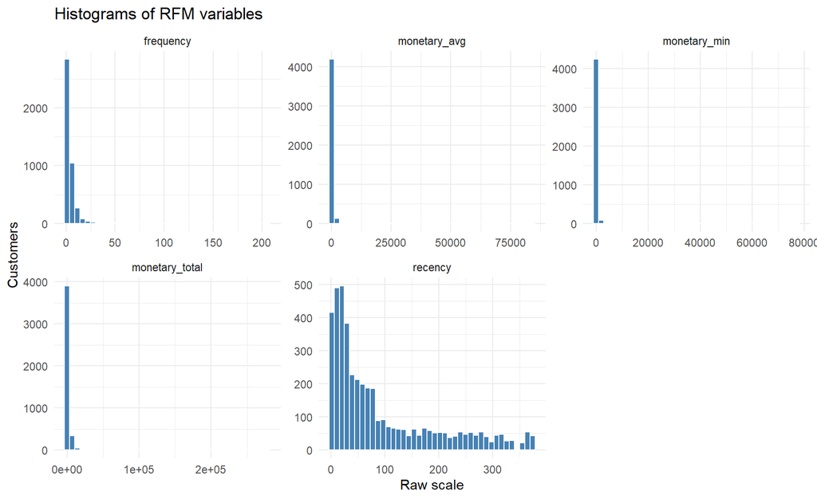

```r
eda <- run_eda_service(rfm_raw, rfm_features)

eda$plots$histograms
```

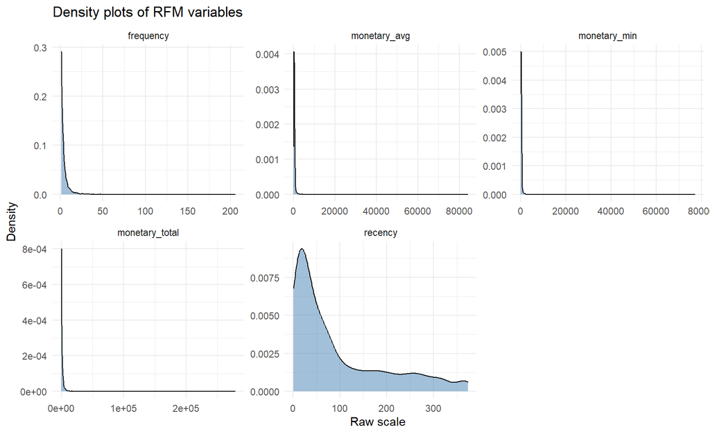

```r
eda$plots$densities
```

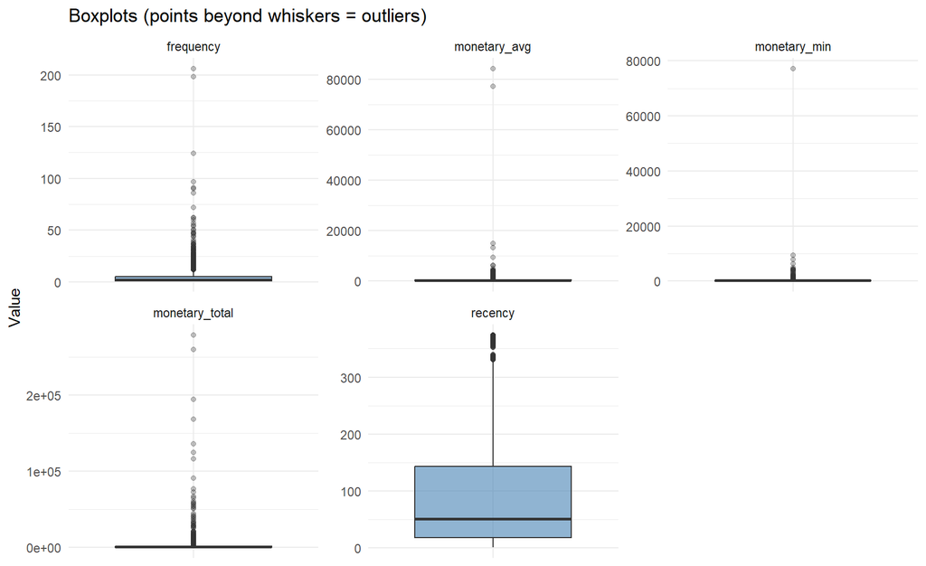

```r
eda$plots$box
```

```r
save_artifact(eda$plots$histograms, "eda_histograms_raw.png")
save_artifact(eda$plots$densities,  "eda_densities_raw.png")
```

Consequently, a logarithmic transformation was applied using the `log1p()` function; this approach compresses very large values and expands smaller ones, helping the skewed distribution more closely approximate a normal distribution.

As can be seen, the logarithmic transformation brings Fisher’s skewness coefficient closer to 0, resulting in more symmetric data. It is worth noting that this is the dataset used to train the models; this step ensures that the models are not biased by the underlying data distribution or unduly influenced by outliers. Even so, a trend is evident: customers tend to have a low purchase frequency, with values close to zero. Meanwhile, the “recency” metric shows that the majority of data points fall within 100 days of the last purchase—a finding that confirms our earlier observation that most customers remain active.

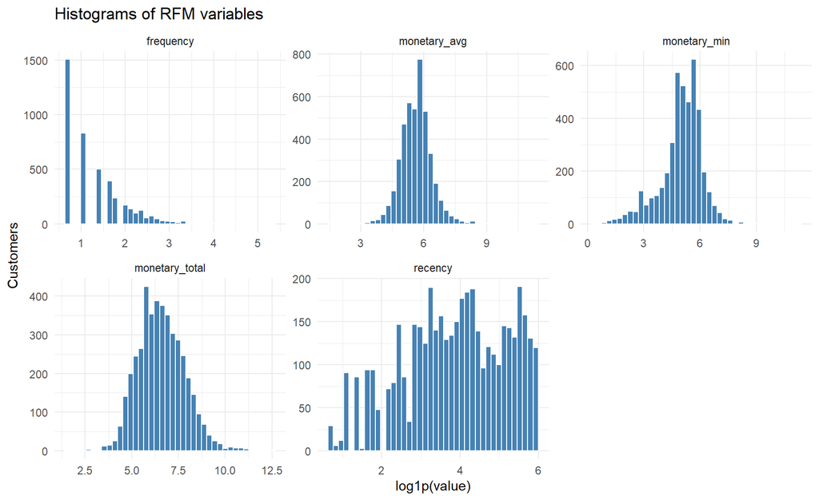

```r
eda <- run_eda_service(rfm_raw, rfm_features, TRUE)

eda$plots$histograms
```

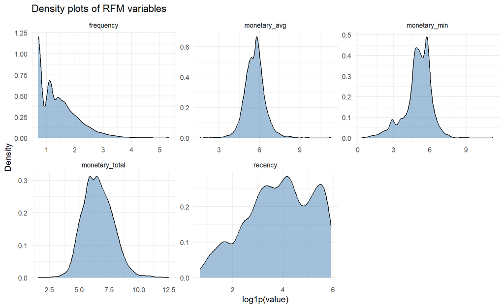

```r
eda$plots$densities
```

```r
kable(eda$skewness, digits = 2, caption = "Skewness before and after log1p")
```

Skewness before and after log1p

| variable | skew_before | skew_after |
| --- | --- | --- |
| recency | 1.24 | -0.33 |
| frequency | 11.94 | 1.21 |
| monetary_total | 19.56 | 0.40 |
| monetary_min | 57.61 | -0.79 |
| monetary_avg | 41.43 | 0.28 |

```r
save_artifact(eda$plots$histograms, "eda_histograms_log1p.png")
save_artifact(eda$plots$densities,  "eda_densities_log1p.png")
```

The following charts show the relationship between active and inactive (or churned) customers it is evident that the majority of customers have made purchases within the last 90 days. It should be noted that this includes both new customers and existing customers who have purchased recently. The chart showing the number of orders or purchases indicates that the largest segment of active customers consists of new customers who have bought recently, rather than repeat customers (those who have made subsequent purchases).

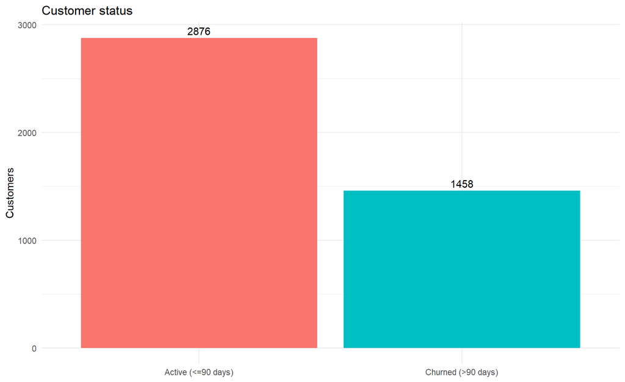

```r
eda$plots$churn_bar
```

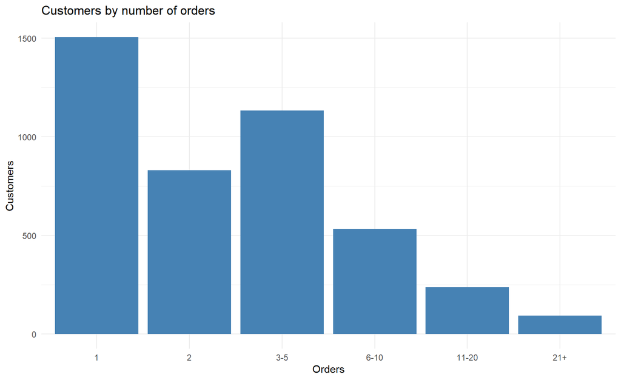

```r
eda$plots$frequency_bar
```

```r
save_artifact(eda$plots$churn_bar,  "eda_churn_bar.png")
save_artifact(eda$plots$frequency_bar, "eda_frequency_bar.png")
```

On the other hand, it can be observed that outliers are concentrated at the upper end of the frequency and expenditure distributions (reaching a maximum of 9.7% for any given variable). These are very likely wholesale accounts. They are retained because they represent genuine commercial clients; however, as they dominate the variance, they provide an additional reason for using logarithmic scales.

As can be seen in the following boxplots—broken down by active and inactive customers—the behavior of the variables under study is evident. Of particular note is the behavior of the frequency variable: the data for active customers suggest a higher proportion of repeat customers compared to new customers—contrary to what had previously been speculated.

[figure not shown]

```r
eda$plots$box
```

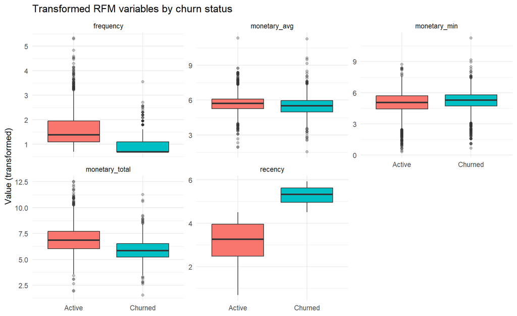

```r
eda$plots$box_by_churn
```

```r
kable(eda$outliers, digits = 1, caption = "Outliers by the 1.5 x IQR rule")
```

Outliers by the 1.5 x IQR rule

| variable | q1 | q3 | outliers | outlier_pct |
| --- | --- | --- | --- | --- |
| recency | 18.1 | 143.1 | 153 | 3.5 |
| frequency | 1.0 | 5.0 | 278 | 6.4 |
| monetary_total | 304.2 | 1631.6 | 421 | 9.7 |
| monetary_min | 94.8 | 307.6 | 231 | 5.3 |
| monetary_avg | 177.2 | 423.4 | 293 | 6.8 |

```r
save_artifact(eda$plots$box, "eda_box_log1p.png")
save_artifact(eda$plots$box_by_churn,  "eda_box_by_churn.png")
```

# 4. Clustering: K-means and hierarchical

To standardize the variables of interest (mean of 0 and standard deviation of 1), the `scale()` function is used. This ensures that clustering algorithms based on mathematical distances (such as Euclidean distance) are not disproportionately influenced by certain variables simply due to the magnitude of their values.

```r
clu <- run_clustering_service(rfm_features, rfm_raw)

cat("Optimal k (K-means, silhouette):", clu$k_optimal_kmeans, "\n")
```

```
## Optimal k (K-means, silhouette): 2
```

```r
cat("Optimal k (hierarchical, silhouette):", clu$k_optimal_hclust, "\n")
```

```
## Optimal k (hierarchical, silhouette): 2
```

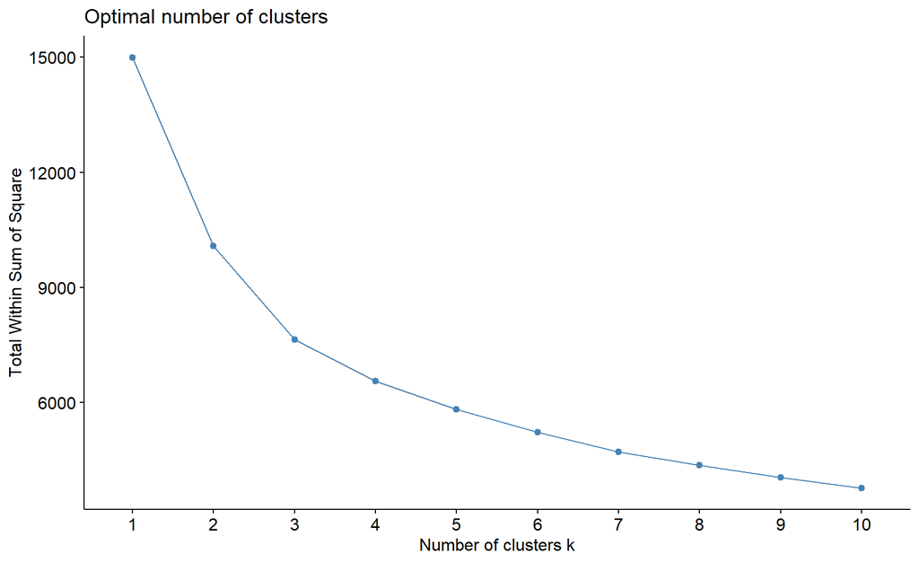

```r
clu$plots$elbow
```

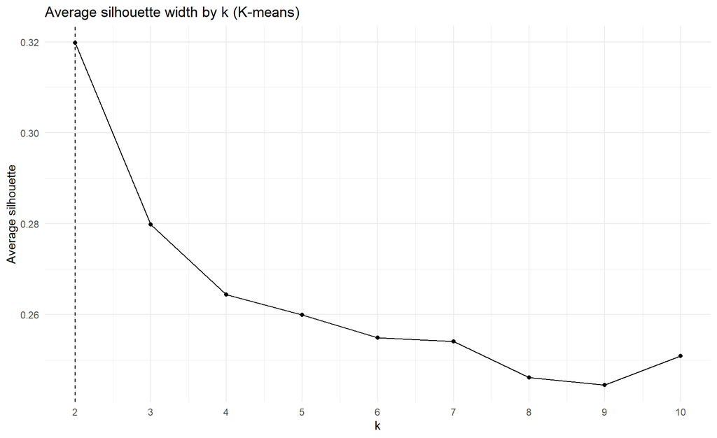

```r
clu$plots$silhouette
```

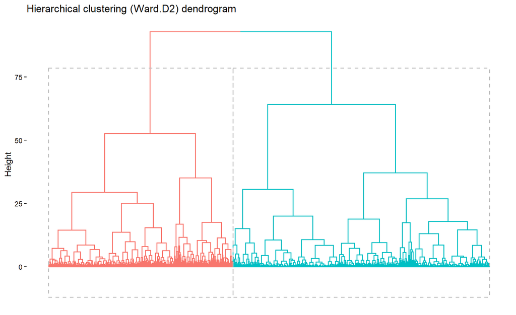

```r
clu$plots$dendrogram
```

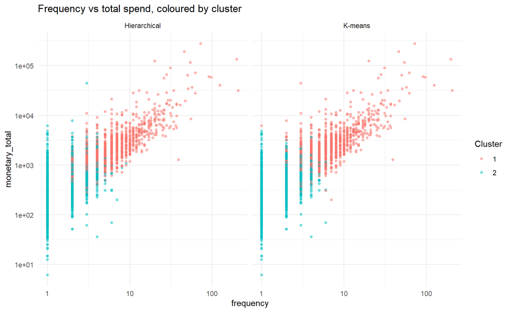

```r
clu$plots$scatter_frequency_spend
```

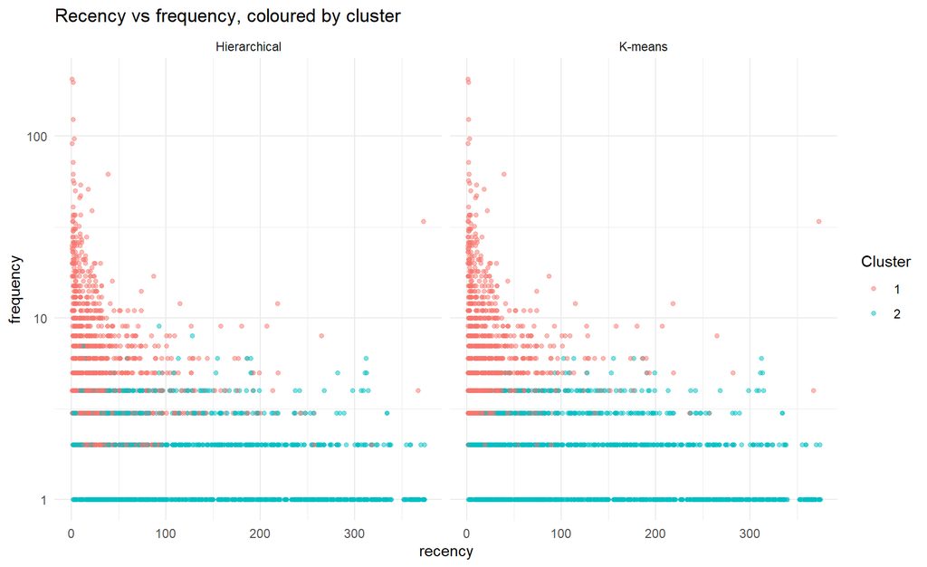

```r
clu$plots$scatter_recency_frequency
```

```r
kable(clu$crosstab, caption = "Cluster agreement: K-means vs hierarchical")
```

Cluster agreement: K-means vs hierarchical

| 1 | 2 |
| --- | --- |
| 989 | 110 |
| 265 | 1636 |

```r
kable(clu$profiles$kmeans, caption = "K-means segment profiles (raw scale)")
```

K-means segment profiles (raw scale)

| cluster | customers | share_pct | mean_recency_days | median_frequency | mean_total_spend | mean_avg_order | churn_rate_pct |
| --- | --- | --- | --- | --- | --- | --- | --- |
| 1 | 1099 | 36.6 | 28.2 | 6 | 4498.7 | 475.0 | 5.1 |
| 2 | 1901 | 63.4 | 130.5 | 1 | 501.6 | 322.5 | 50.3 |

```r
kable(clu$profiles$hclust, caption = "Hierarchical segment profiles (raw scale)")
```

Hierarchical segment profiles (raw scale)

| cluster | customers | share_pct | mean_recency_days | median_frequency | mean_total_spend | mean_avg_order | churn_rate_pct |
| --- | --- | --- | --- | --- | --- | --- | --- |
| 1 | 1254 | 41.8 | 34.4 | 5 | 3967.1 | 435.7 | 8.1 |
| 2 | 1746 | 58.2 | 135.2 | 1 | 528.6 | 337.2 | 52.2 |

```r
save_artifact(clu$plots$elbow, "clust_elbow.png")
save_artifact(clu$plots$silhouette, "clust_silhouette.png")
save_artifact(clu$plots$dendrogram, "clust_dendrogram.png")
save_artifact(clu$plots$scatter_frequency_spend, "clust_scatter_freq_spend.png")
save_artifact(clu$plots$scatter_recency_frequency, "clust_scatter_rec_freq.png")
```

As can be seen, although the elbow method did not show an abrupt change as the value of $k$ increased—which would have helped determine the optimal value—the higher silhouette score indicates that the optimal number of clusters ($k$) is 2. Similarly, the hierarchical clustering, as represented in the dendrogram, also suggests that the optimal number of clusters is 2. This is to be expected, given that the ultimate goal of the model is to distinguish active customers from those who have stopped making purchases.

In both cases, the groups are representative and divide the dataset into approximately 40% (Group 1) and 60% (Group 2). When examining the customer churn rate, we can observe that the actual churn rate is significantly lower in Group 1 (5.1% for k-means, 8.1% for hierarchical clustering) compared to Group 2 (50.3% for k-means, 52.2% for hierarchical clustering). These results suggest a segmentation that effectively separates the data into a group of active customers and a group of inactive ones. Furthermore, we can identify specific characteristics that define these groups. For instance, Group 1 appears to consist of wholesale or high-volume customers, with an average of 5 to 6 recorded purchases and an average transaction value between 4,000 and 4,500. In contrast, Group 2 corresponds to customers who made a single purchase and did not return.

In addition to the above, the scatter plots show that Group 1 consists of customers with higher purchase volumes and greater purchase frequency—in other words, customers who are loyal to the company—whereas Group 2 is composed primarily of customers who have made only a single purchase. Furthermore, it is evident that the model does not categorize new customers (defined as those who have made a single purchase within the last 90 days) as “loyal customers,” which indicates that, given the current number of defined groups, the model fails to identify potential loyal customers.

## 4.1 Optimal k vs other k

```r
K_MANUAL <- 3

cmp_k <- compare_k_solutions(rfm_features, rfm_raw, k_manual = K_MANUAL, auto = clu)

kable(cmp_k$summary, digits = 3,
      caption = "Quality of the two K-means solutions")
```

Quality of the two K-means solutions

| solution | k | avg_silhouette | explained_variance_pct | smallest_segment_pct |
| --- | --- | --- | --- | --- |
| Silhouette (k=2) | 2 | 0.32 | 32.817 | 36.633 |
| Manual (k=3) | 3 | 0.28 | 49.102 | 28.000 |

```r
cat("Adjusted Rand index between the two solutions:", round(cmp_k$ari, 3), "\n")
```

```
## Adjusted Rand index between the two solutions: 0.406
```

```r
kable(cmp_k$crosstab, caption = "Cross-tab: silhouette solution vs manual solution")
```

Cross-tab: silhouette solution vs manual solution

| 1 | 2 | 3 |
| --- | --- | --- |
| 221 | 840 | 38 |
| 912 | 0 | 989 |

```r
cmp_k$plot
```

[output not shown]

```r
kable(cmp_k$profiles$auto, caption = "Segment profiles: silhouette solution")
```

Segment profiles: silhouette solution

| cluster | customers | share_pct | mean_recency_days | median_frequency | mean_total_spend | mean_avg_order | churn_rate_pct |
| --- | --- | --- | --- | --- | --- | --- | --- |
| 1 | 1099 | 36.6 | 28.2 | 6 | 4498.7 | 475.0 | 5.1 |
| 2 | 1901 | 63.4 | 130.5 | 1 | 501.6 | 322.5 | 50.3 |

```r
kable(cmp_k$profiles$manual, caption = "Segment profiles: manual solution")
```

Segment profiles: manual solution

| cluster | customers | share_pct | mean_recency_days | median_frequency | mean_total_spend | mean_avg_order | churn_rate_pct |
| --- | --- | --- | --- | --- | --- | --- | --- |
| 1 | 1133 | 37.8 | 109.5 | 2 | 1088.8 | 555.3 | 41.1 |
| 2 | 840 | 28.0 | 22.8 | 7 | 5194.3 | 413.3 | 3.2 |
| 3 | 1027 | 34.2 | 132.4 | 1 | 293.0 | 154.7 | 50.5 |

```r
save_artifact(cmp_k$plot, "clust_k_comparison.png")
save_artifact(cmp_k$summary, "clust_k_comparison_summary.csv")
```

From this, we can see that it is possible to implement loyalty campaigns designed to convert potential customers into loyal ones, while also identifying the factors that lead existing loyal customers to continue choosing the brand.

# 5. Churn classification: logistic regression and SVM

For this exercise, the data are split in a 70/30 ratio, applying stratification based on the churn label so that both sets maintain the same churn rate. The “recency” variable is excluded from the predictors because it defines the label we aim to identify using the applied supervised model.

```r
clf <- run_classification_service(rfm_features)

kable(clf$class_balance, digits = 2, caption = "Churn ratio in train and test sets")
```

Churn ratio in train and test sets

| churn | n | set | pct |
| --- | --- | --- | --- |
| Retained | 2014 | Train | 66.36 |
| Churned | 1021 | Train | 33.64 |
| Retained | 862 | Test | 66.36 |
| Churned | 437 | Test | 33.64 |

```r
kable(clf$evaluations$logistic$confusion, caption = "Confusion matrix: logistic regression (test)")
```

Confusion matrix: logistic regression (test)

|  | Retained | Churned |
| --- | --- | --- |
| Retained | 671 | 201 |
| Churned | 191 | 236 |

```r
kable(clf$evaluations$svm$confusion, caption = "Confusion matrix: SVM radial (test)")
```

Confusion matrix: SVM radial (test)

|  | Retained | Churned |
| --- | --- | --- |
| Retained | 699 | 227 |
| Churned | 163 | 210 |

```r
kable(clf$metrics, digits = 3, caption = "Test-set performance, baseline models")
```

Test-set performance, baseline models

| model | accuracy | recall | specificity | precision | f1 | balanced_accuracy | TP | TN | FP | FN |
| --- | --- | --- | --- | --- | --- | --- | --- | --- | --- | --- |
| Logistic regression | 0.698 | 0.540 | 0.778 | 0.553 | 0.546 | 0.659 | 236 | 671 | 191 | 201 |
| SVM (radial) | 0.700 | 0.481 | 0.811 | 0.563 | 0.519 | 0.646 | 210 | 699 | 163 | 227 |

```r
cat("Best balance between false positives and false negatives:", clf$best, "\n")
```

```
## Best balance between false positives and false negatives: Logistic regression
```

Given that the objective is to correctly identify customers who churn, Logistic Regression is the better choice of the two models, despite having a slightly lower overall accuracy.

In this context, the critical metric is Recall (Sensitivity), as it captures a higher number of churning customers. In this regard, Logistic Regression outperforms the SVM model by nearly 6 percentage points (54.0% versus 48.1%). Specifically, out of a total of 437 customers who actually churned (TP + FN), Logistic Regression successfully identifies 236 (TP) but misses 201 (FN). Meanwhile, the SVM model fails to detect 227 customers. In this case study, losing a customer who intends to leave is generally far more costly than sending a proactive promotion to someone who had no intention of leaving (FP).

Nevertheless, based on the initial results, both models are failing to identify nearly half of the customers at risk of churning.

# 6. 10-fold cross-validation

To assess the stability and reliability of the implemented models, a 10-iteration cross-validation is performed for both models, and the accuracy, recall, and F1-score for each iteration are extracted using `resamples()`.

```r
cvs <- run_cv_service(clf$split$train)

kable(cvs$fold_table, digits = 3, caption = "Mean and SD of metrics across the 10 folds")
```

Mean and SD of metrics across the 10 folds

| Model | Metric | mean | sd |
| --- | --- | --- | --- |
| Logistic | Accuracy | 0.718 | 0.018 |
| Logistic | F1 | 0.580 | 0.020 |
| Logistic | Recall | 0.579 | 0.033 |
| SVM | Accuracy | 0.717 | 0.020 |
| SVM | F1 | 0.554 | 0.028 |
| SVM | Recall | 0.522 | 0.041 |

```r
cat("Most stable model (lowest SD of F1):", cvs$stability, "\n")
```

```
## Most stable model (lowest SD of F1): Logistic
```

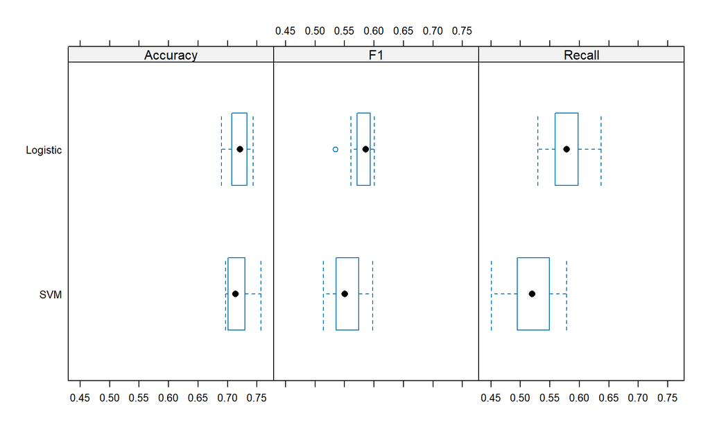

```r
bwplot_obj <- lattice::bwplot(cvs$resamples, metric = c("Accuracy", "Recall", "F1"))
print(bwplot_obj)
```

In general, the standard deviations (SD) of Logistic Regression are lower across all three metrics. In the boxplots, the boxes and whiskers of SVM are wider (especially for Recall, which ranges from 0.45 to 0.58), indicating that the SVM model is more sensitive to how the data is divided.

Additionally, the boxplot for Logistic Regression’s Recall is noticeably shifted to the right (around 0.58), while SVM’s lags behind (around 0.52). Even the worst-performing Logistic Regression (left whisker at ~0.53) surpasses the median of SVM.

Similarly, the boxplot for Logistic Regression’s F1-Score is very narrow (SD = 0.020), with almost all its results concentrated around 0.58. Although it has an isolated outlier (the point on the left near 0.53), its overall performance is still above the bulk of SVM’s results.

It is concluded that Logistic Regression is the most suitable, stable, and reliable of the two models for predicting customer churn. When evaluating multiple data partitions, Logistic Regression not only achieves a higher average across key metrics but also demonstrates less dispersion in its results.

# 7. Hyperparameter tuning and final evaluation

```r
tun <- run_tuning_service(clf$split$train, clf$split$test, baseline_metrics = clf$metrics)

cat("Best glmnet parameters: alpha =", tun$best_params$logistic$alpha,
    ", lambda =", signif(tun$best_params$logistic$lambda, 3), "\n")
```

```
## Best glmnet parameters: alpha = 0 , lambda = 0.00599
```

```r
cat("Best SVM parameters: sigma =", tun$best_params$svm$sigma,
    ", C =", tun$best_params$svm$C, "\n")
```

```
## Best SVM parameters: sigma = 1 , C = 0.25
```

```r
kable(tun$tuned_metrics, digits = 3, caption = "Test-set performance, tuned models")
```

Test-set performance, tuned models

[output not shown]

```r
kable(tun$gains, digits = 3, caption = "Gains from tuning (tuned minus baseline)")
```

Gains from tuning (tuned minus baseline)

[output not shown]

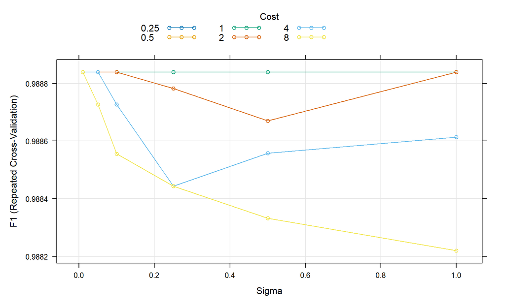

```r
plot(tun$fits$svm)
```

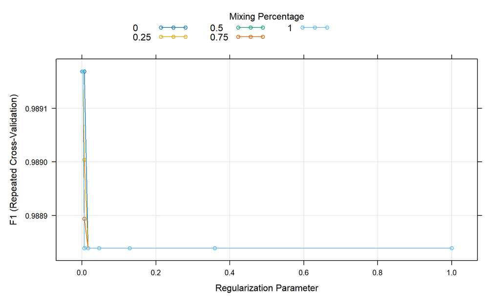

```r
plot(tun$fits$logistic)
```

The graphs show that both models collapsed into a trivial classifier (predicting the same class for all customers) and that optimization based on the F1-score is rewarding this lack of discrimination. A flat horizontal line at approximately 0.98885 is visible in the graphs; this does not represent high performance, but rather the F1-score obtained when 100% of the data is predicted as positive in a scenario where one class constitutes the majority of the sample.

For the SVM model, at low cost values (Cost = 0.25, 0.5, 1), the lines remain completely flat at 0.98885 across all Sigma values. This indicates that the model fails to separate the classes. Conversely, when the penalty is increased (Cost = 4 and 8), the SVM model is compelled to account for the minority class, leading it to classify some customers as “negative.” In making actual predictions, the model incurs some errors, causing the F1 score to drop slightly (to 0.9882). Since the `caret` package aims to maximize the F1 score, it discards the models that actually attempt to perform classification (Cost = 4, 8) and selects Cost = 0.25, because “doing nothing” yields a higher F1 score.

On the other hand, in the case of logistic regression, for any regularization parameter ($\lambda$) greater than 0.02, the penalty drives all coefficients to zero, and the model collapses into the exact same flat line (0.98885). Furthermore, as $\lambda$ approaches 0 (0.00599), the model incorporates the variables and achieves a marginal increase of +0.0003 in the F1 score (0.98915); however, this remains insufficient to cross the decision threshold on the test set.

```r
save_artifact(clf$metrics, "classification_baseline_metrics.csv")
save_artifact(tun$tuned_metrics, "classification_tuned_metrics.csv")
save_artifact(cvs$fold_table, "cv_fold_summary.csv")
save_artifact(rfm_raw, "rfm_customers.csv")
```